# Reproducible Research: Peer Assessment 1

MODULE 5

April 18, 2015

========================================================================================

This **assignment** makes use of data from a personal activity monitoring device. This device collects data at `5 minute intervals` through out the day. The data consists of two months of data from an anonymous individual collected during the months of October and November, 2012 and include the number of `steps` taken in `5 minute intervals` each day.

```r
# Loading libraries
library(plyr)
library(ggplot2)
library(gridExtra)
library(formatR)
library(lubridate)
```

## Loading and preprocessing the data

```r
# Cleaning working directory
rm(list = ls())

# Reading the data file
data <- read.csv("activity.csv", colClasses = "character")

# Formating the columns/variables
data$steps <- as.numeric(data$steps)
data$date <- as.Date(data$date)
data$interval <- as.numeric(data$interval)

# Eliminating NAs records for the sake of comparing results
goodRds <- complete.cases(data)
dataNoNA <- data[goodRds, ]
```

## Analysis of the data

### 1. What is the mean of the total number of steps taken per day?

```r
# Grouping the data by day and summing up the steps Using the original data
gpDataOri <- ddply(data, .(date), summarize, steps = sum(steps, na.rm = TRUE))

# Using the data with no NAs
gpData1 <- ddply(dataNoNA, .(date), summarize, steps = sum(steps, na.rm = TRUE))

# Calculating mean & median of the number of steps per day Using the
# original data
meanStepsDayOri <- round(mean(gpDataOri$steps), 2)
medianStepsDayOri <- round(median(gpDataOri$steps), 2)

# Using the data with no NAs
meanStepsDay1 <- round(mean(gpData1$steps), 2)
medianStepsDay1 <- round(median(gpData1$steps), 2)

# Histogram of number of steps per day Using the original data
g1 <- ggplot(gpDataOri, aes(x = steps)) + geom_histogram(binwidth = (max(gpDataOri$steps) -
    min(gpDataOri$steps))/5) + geom_vline(xintercept = meanStepsDayOri, colour = "red",
    size = 1) + geom_vline(xintercept = medianStepsDayOri, colour = "green",
    size = 0.5) + ggtitle("Original dataset") + theme(plot.title = element_text(lineheight = 0.8,
    size = 12)) + annotate("text", label = "Mean: vertical red line", x = 20000,
    y = 22, size = 3, colour = "red") + annotate("text", label = "Median: vertical green line",
    x = 20000, y = 21, size = 3, colour = "green")

# Using the data with no NAs
g2 <- ggplot(gpData1, aes(x = steps)) + geom_histogram(binwidth = (max(gpData1$steps) -
    min(gpData1$steps))/5) + geom_vline(xintercept = meanStepsDay1, colour = "red",
    size = 1) + geom_vline(xintercept = medianStepsDay1, colour = "green", size = 0.5) +
    ggtitle("Dataset with no NAs") + theme(plot.title = element_text(lineheight = 0.8,
    size = 12)) + annotate("text", label = "Mean: vertical red line", x = 22000,
    y = 22, size = 3, colour = "red") + annotate("text", label = "Median: vertical green line",
    x = 22000, y = 21, size = 3, colour = "green")
```

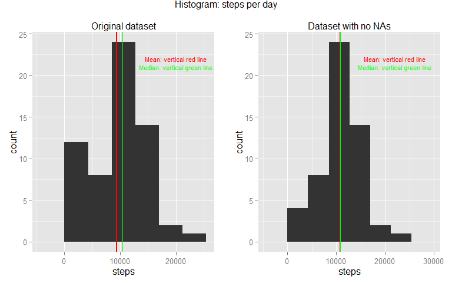

```r
grid.arrange(g1, g2, ncol = 2, main = "Histogram: steps per day")
```

The observed statistics of the total number of steps taken per day are the following:

- Using the original data:
  - **Mean =** 9,354
  - **Median =** 10,395
- Using the data with no NAs
  - **Mean =** 10,766
  - **Median =** 10,765

### 2. What is the average daily activity pattern?

In this section, the dataset with no NAs was used.

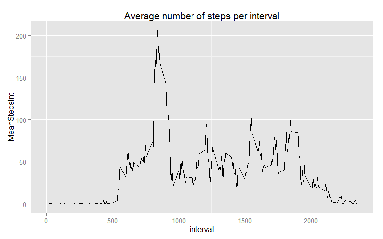

```r
# Grouping the data by interval and averaging the steps
gpData2 <- ddply(dataNoNA, .(interval), summarize, MeanStepsInt = mean(steps,
    na.rm = TRUE))

# Time series plot of average number of steps per interval
g1 <- ggplot(gpData2, aes(x = interval, y = MeanStepsInt))
g1 + geom_line() + ggtitle("Average number of steps per interval")
```

```r
maxInt <- gpData2[which.max(gpData2$MeanStepsInt), 1]
maxAvg <- gpData2[which.max(gpData2$MeanStepsInt), 2]
```

The 5-minute interval, on average across all the days in the dataset, that contains the maximum number of steps is the interval **835**, with an average number of steps equal to **206.17**.

### 3. Imputing missing values

The total number of rows in the original dataset with `NAs` is 2,304.

A new dataset was created following the next steps:

- Copying the original dataset
- Identifying the rows with `NAs`
- Replacing the `NAs` with the mean number of steps of the corresponding interval calculated in the previous section 2.

```r
# Replacing NAs in column 'steps' in a copy of the original dataset
dataNAfill <- data
dataNAfill$indMatch <- match(dataNAfill$interval, gpData2$interval)

dataNAfill$steps <- ifelse(is.na(dataNAfill$steps), gpData2[dataNAfill$indMatch,
    2], dataNAfill$steps)
```

```r
# Grouping the data by day and summing up the steps
gpData3 <- ddply(dataNAfill, .(date), summarize, steps = sum(steps, na.rm = TRUE))

# Calculating mean & median of number of steps per day
meanStepsDay3 <- round(mean(gpData3$steps), 2)
medianStepsDay3 <- round(median(gpData3$steps), 2)

# Histogram of number of steps per day
g3 <- ggplot(gpData3, aes(x = steps)) + geom_histogram(aes(y = ..density..),
    binwidth = (max(gpData3$steps) - min(gpData3$steps))/5) + geom_density() +
    geom_vline(xintercept = meanStepsDay3, colour = "red", size = 1) + ggtitle("Histogram: steps per day - Density") +
    theme(plot.title = element_text(lineheight = 0.8, size = 12)) + annotate("text",
    label = "Mean: vertical red line", x = 20000, y = 0.00024, size = 3, colour = "red")

g4 <- ggplot(gpData3, aes(x = steps)) + geom_histogram(binwidth = (max(gpData3$steps) -
    min(gpData3$steps))/5) + geom_vline(xintercept = medianStepsDay3, colour = "green",
    size = 1) + ggtitle("Histogram: steps per day - Count") + theme(plot.title = element_text(lineheight = 0.8,
    size = 12)) + annotate("text", label = "Median: vertical green line", x = 22000,
    y = 25, size = 3, colour = "green")
```

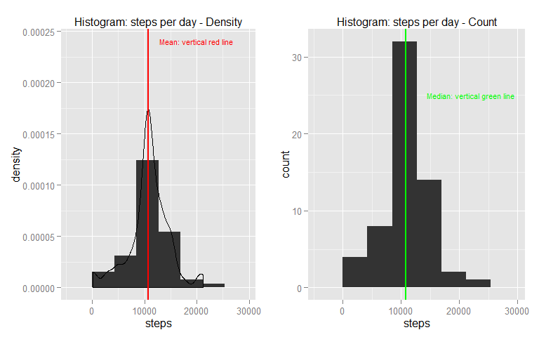

```r
grid.arrange(g3, g4, ncol = 2)
```

For the new dataset, where the `NAs` where replaced, the observed statistics are:

- **Mean =** 10,766
- **Median =** 10,766

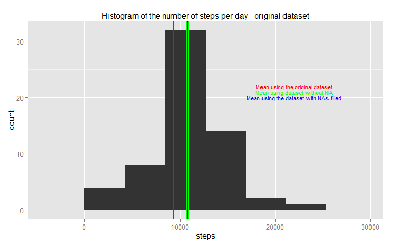

```r
# Using the dataset with NAs filled-in
g5 <- ggplot(gpData3, aes(x = steps))
g5 + geom_histogram(binwidth = (max(gpData3$steps) - min(gpData3$steps))/5) +
    geom_vline(xintercept = meanStepsDayOri, colour = "red", size = 1) + geom_vline(xintercept = meanStepsDay1,
    colour = "green", size = 2) + geom_vline(xintercept = meanStepsDay3, colour = "blue",
    size = 0.7) + theme(plot.title = element_text(lineheight = 0.8, size = 12)) +
    annotate("text", label = "Mean using the original dataset", x = 22000, y = 22,
        size = 3, colour = "red") + annotate("text", label = "Mean using dataset without NA",
    x = 22000, y = 21, size = 3, colour = "green") + annotate("text", label = "Mean using the dataset with NAs filled",
    x = 22000, y = 20, size = 3, colour = "blue") + ggtitle("Histogram of the number of steps per day - original dataset")
```

### 4. Are there differences in activity patterns between weekdays and weekends?

Using the dataset with the filled-in missing values from the previous section 3, the activity patterns between weekdays and weekends was analyzed by doing the following:

- Creating a new factor variable in the dataset with two levels: “weekday” and “weekend” to indicate whether a given date is a “weekday” or a “weekend” day.
- Grouping the data by type of day (“weekday”, “weekend”) and interval
- Calculating the mean of the number of steps per interval, accross all “weekday” or “weekend” days.

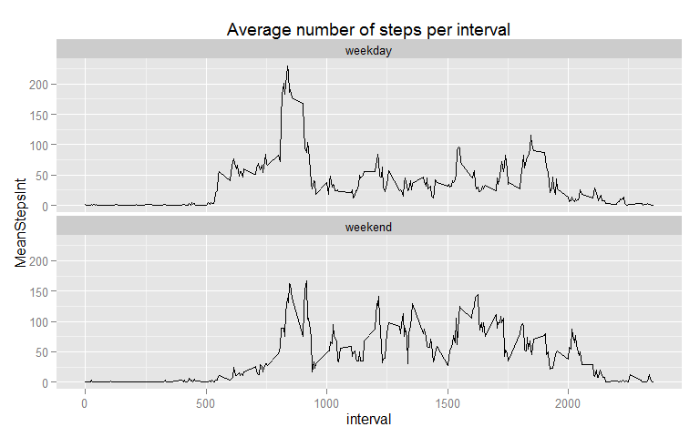

```r
# Creating the new factor variable
dataNAfill$tpDay <- factor(ifelse(wday(dataNAfill$date) %in% c(1, 7), "weekend",
    "weekday"))

# Grouping by tpDay and interval and calculating the mean
gpData4 <- ddply(dataNAfill, .(tpDay, interval), summarize, MeanStepsInt = mean(steps,
    na.rm = TRUE))

# Time series plot of the average number of steps per interval
g6 <- ggplot(gpData4, aes(x = interval, y = MeanStepsInt))
g6 + geom_line() + ggtitle("Average number of steps per interval") + facet_wrap(~tpDay,
    ncol = 1)
```

```r
# Identifying the intervals with the maximum number of steps
Data4wday <- subset(gpData4, tpDay == "weekday")
Data4wend <- subset(gpData4, tpDay == "weekend")

maxIntwday <- Data4wday[which.max(Data4wday$MeanStepsInt), 2]
maxAvgwday <- Data4wday[which.max(Data4wday$MeanStepsInt), 3]

maxIntwend <- Data4wend[which.max(Data4wend$MeanStepsInt), 2]
maxAvgwend <- Data4wend[which.max(Data4wend$MeanStepsInt), 3]
```

The **5-minute intervals**, on average across all `weekday` or `weekend` days in the dataset, that contain the maximum number of steps are:

- For `weekday` days: **835**
- For `weekend` days: **915**

With an **average** number of steps equal to:

- For `weekday` days: **230.38**
- For `weekend` days: **166.64**